# project2

### DATA620 - Project 2

#### Michael Ippolito

6/20/2022

1. Identify a large 2-node network dataset—you can start with a dataset in a repository. Your data should meet the criteria that it consists of ties between and not within two (or more) distinct groups.
2. Reduce the size of the network using a method such as the island method described in chapter 4 of social network analysis.
3. What can you infer about each of the distinct groups? \ \ You may work in a small group on the project. Your code and analysis should be delivered in an IPython Notebook by end of day Sunday.

### Project Overview

For this project, I'll analyze a large bipartite dataset of book readers. Nodes are either readers (top nodes) or books (bottom nodes). This is a large dataset (271,000 books and 278,000 readers). To save processing time, only the first 20,000 of each will be analyzed. Readers have been deidentified but have location and ages provided. Books are listed by ISBN. The main goal is to identify similar books based on the readers who read them.

Soure: http://www.informatik.uni-freiburg.de/~cziegler/BX/

### Link to video presentation

[Video](https://github.com/mmippolito/cuny_data620_project2/blob/main/ippolito_video.mp4?raw=true)

```python
# Load libraries
#import pkg_resources
#pkg_resources.require("networkx==2.6.3")
import networkx as nx
import networkx.algorithms.bipartite as bipartite
print("Using nx version", nx.__version__, "due to error module 'scipy.sparse' has no attribute 'coo_array.'")
import matplotlib.pyplot as plt
import csv
import os
import requests
import numpy as np
from scipy import stats
import pandas as pd
from collections import Counter
import plotly.express as px
import plotly.io as pio
pio.renderers.default = 'jupyterlab'    # set ploty renderer so graphs show up in HTML output
```

```
Using nx version 2.6.3 due to error module 'scipy.sparse' has no attribute 'coo_array.'
```

### Fetch data

First, fetch the data from my github repo if it already isn't on the local drive.

```python
# Fetch data from github repo and store in current directory
def fetch_data(fn):
    if not os.path.exists(fn):
        print('Downloading', fn)
        try:
            r = requests.get('https://github.com/mmippolito/cuny_data620_project2/blob/main/' + fn + '?raw=true').text
            fh = open(fn, 'w', encoding='utf-8')
            fh.write(r)
            fh.close()
        except:
            return 1
    return 0

# Fetch data
err = 0
err += fetch_data('BX-Users.csv')
err += fetch_data('BX-Books.csv')
err += fetch_data('BX-Book-Ratings.csv')
if err > 0:
    assert(False, 'An error occured trying to download or save one or more of the data files.')
```

### Populate graph

Create and populate the graph by reading in user nodes, book nodes, and edges. Only examine the first 20,000 nodes of each type to speed up processing time (I let nx.draw run for an hour with the full set before cancelling it).

```python
# Create graph object
g = nx.Graph()

# Populate user nodes; data looks like this:
# "User-ID";"Location";"Age"
fh = open('BX-Users.csv', 'r')
rdr = csv.reader(fh, delimiter=';')
ct = 0

# Loop through each row of the csv
for row in rdr:
    ct += 1
    if row[0] == 'User-ID':    # skip header
        continue
    g.add_node(int(row[0]), loc=row[1], age=row[2], bipartite=0)    # add the node for this row
    if ct > 20000:    # only take the first 20,000 nodes to save time
        break
fh.close()

# Populate book nodes; data looks like this:
# "ISBN";"Book-Title";"Book-Author";"Year-Of-Publication";"Publisher";"Image-URL-S";"Image-URL-M";"Image-URL-L"
fh = open('BX-Books.csv', 'r')
rdr = csv.reader(fh, delimiter=';')
ct = 0
for row in rdr:
    ct += 1
    if row[0] == 'ISBN':    # skip header
        continue
    g.add_node(str(row[0]), title=row[1], author=row[2], year=row[3], pub=row[4], bipartite=1)
    if ct > 20000:
        break
fh.close()

# Add edges; data looks like this:
# "User-ID";"ISBN";"Book-Rating"
fh = open('BX-Book-Ratings.csv', 'r')
rdr = csv.reader(fh, delimiter=';')
for row in rdr:
    if row[0] == 'User-ID':    # skip header
        continue
    if int(row[0]) in g.nodes and row[1] in g.nodes:
        g.add_edge(int(row[0]), str(row[1]), wt=float(row[2]))
fh.close()
```

### Function to trim edges

Define function to trim edges based on weight.

```python
# Define function to trim edges based on weight; modified from source:
# Maksim Tsvetovat & Alexander Kouznetsov, Social Network Analysis for Startups, 2011
def trim_edges(g, weight=1):
    g2 = nx.Graph()
    for f, to, edata in g.edges(data=True):
        if edata['weight'] > weight:
            if f not in g2.nodes:
                if g.nodes(data=True)[f]['bipartite'] == 0:
                    g2.add_node(f, loc=g.nodes(data=True)[f]['loc'], age=g.nodes(data=True)[f]['age'], bipartite=0)
                else:
                    g2.add_node(f, title=g.nodes(data=True)[f]['title'], author=g.nodes(data=True)[f]['author'], year=g.nodes(data=True)[f]['year'], pub=g.nodes(data=True)[f]['pub'], bipartite=1)
            if to not in g2.nodes:
                if g.nodes(data=True)[to]['bipartite'] == 0:
                    g2.add_node(to, loc=g.nodes(data=True)[to]['loc'], age=g.nodes(data=True)[to]['age'], bipartite=0)
                else:
                    g2.add_node(to, title=g.nodes(data=True)[to]['title'], author=g.nodes(data=True)[to]['author'], year=g.nodes(data=True)[to]['year'], pub=g.nodes(data=True)[to]['pub'], bipartite=1)
            g2.add_edge(f, to, weight=edata['weight'])
    return g2
```

### Projection

Assign top and bottom nodes (users and books, respectively), then project books onto the graph.

```python
# Assign top and bottom nodes (users and books, respectively)
users = [n[0] for n in g.nodes(data=True) if n[1]['bipartite'] == 0]
books = [n[0] for n in g.nodes(data=True) if n[1]['bipartite'] == 1]

# Project weighted users onto graph
gw = bipartite.weighted_projected_graph(g, books)
```

### Evaluate subgraphs

Examine subgraphs of projected graph. These will be books linked with each other via readers.

| Subgraph_Length | Count |
| --- | --- |
| 1 | 1123 |
| 18256 | 1 |
| 4 | 11 |
| 2 | 117 |
| 3 | 51 |
| 8 | 2 |
| 6 | 9 |
| 13 | 1 |
| 5 | 8 |
| 17 | 1 |
| 10 | 1 |
| 7 | 2 |
| 12 | 1 |
| 14 | 1 |

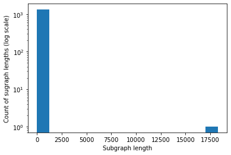

```python
# Get lengths of connected component subgraphs
x = [len(c) for c in nx.connected_components(gw)]
dftmp = pd.DataFrame.from_dict(dict(Counter(x)), orient='index')
dftmp.columns = ['Count']
dftmp.index.name ='Subgraph_Length'
display(dftmp)
plt.hist(x, bins=15)
plt.yscale('log')
plt.xlabel('Subgraph length')
plt.ylabel('Count of sugraph lengths (log scale)')
plt.show()
```

There is one very large subgraph containing 18256 nodes; this is the one we'll want to examine.

### Trim edges

Trim the edges of nodes that are only connected to one or two other nodes.

```
Length before trimming: 20000 , length after trimming: 2352
After trimming, unique lengths of component graphs:
```

| Subgraph_Length | Count |
| --- | --- |
| 2302 | 1 |
| 3 | 5 |
| 2 | 13 |
| 9 | 1 |

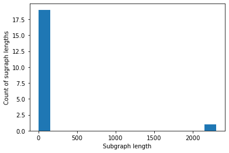

```python
# Trim edges only connected to two other nodes
g2 = trim_edges(gw, weight=2)
print('Length before trimming:', len(gw), ', length after trimming:', len(g2))
x = [len(c) for c in nx.connected_components(g2)]
print('After trimming, unique lengths of component graphs:')
dftmp = pd.DataFrame.from_dict(dict(Counter(x)), orient='index')
dftmp.columns = ['Count']
dftmp.index.name ='Subgraph_Length'
display(dftmp)
plt.hist(x, bins=15)
plt.xlabel('Subgraph length')
plt.ylabel('Count of sugraph lengths')
plt.show()
```

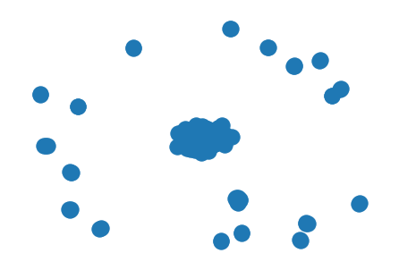

```python
# Draw trimmed graph
nx.draw(g2)
```

### Connected subgraphs

Show connected subgraphs of trimmed graph. We're only interested in the biggest graphs.

```
Sizes of connected subgraphs:
```

|  | Subgraph_size |
| --- | --- |
| 0 | 2302 |
| 1 | 3 |
| 2 | 2 |
| 3 | 2 |
| 4 | 9 |
| 5 | 2 |
| 6 | 2 |
| 7 | 3 |
| 8 | 2 |
| 9 | 2 |
| 10 | 3 |
| 11 | 3 |
| 12 | 2 |
| 13 | 2 |
| 14 | 2 |
| 15 | 2 |
| 16 | 2 |
| 17 | 3 |
| 18 | 2 |
| 19 | 2 |

```
First subgraph witht he large number of nodes: Graph with 2302 nodes and 71030 edges

Next largest subgraph: Graph with 9 nodes and 9 edges
```

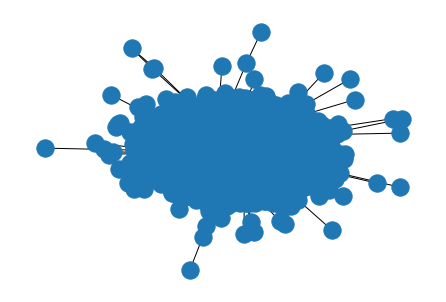

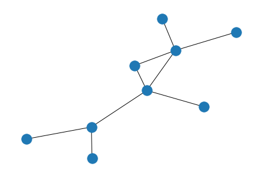

```python
# Show list of connected subgraphs
cc = [c for c in nx.connected_components(g2)]
print('Sizes of connected subgraphs:')
dftmp = pd.DataFrame.from_dict({'Subgraph_size': [len(c) for c in cc]})
display(dftmp)

# This is the first subgraph with the large number of nodes
sg = g2.subgraph(cc[0]).copy()
print('First subgraph witht he large number of nodes:', sg)
print()

# This is the next largest subgraph, with only 9 nodes
sg2 = g2.subgraph(cc[4]).copy()
print('Next largest subgraph:', sg2)
print()

# Draw subgraphs
plt.figure(1)
nx.draw(sg)
plt.figure(2)
nx.draw(sg2)
```

### Centrality metrics

Compute centrality metrics:

1. degree
2. closeness
3. betweenness
4. eigenvector
5. page rank

```python
# Function to display books in a data frame
def bookToDf(centtmp, sgtmp, metricName):
    # cent=sorted list of centrality metrics
    # sg=subgraph
    # metricName=the name of the metric, e.g. degree, closeness, etc

    # first create empty data frame
    df = pd.DataFrame(columns=['Rank', metricName, 'isbn', 'title', 'author', 'year', 'pub', 'bipartite'])

    # loop through each centrality entry, adding each one to the data frame
    for i, b in enumerate(centtmp):
        if i > 9: break    # only use the top ten
        if metricName == 'degree':    # degree uses tuples instead of scalars
            tmpd = {'rank': [i+1], metricName: [b[1]], 'isbn': [b[0]]}    # add rank, the metric, and isbn
            tmpd2 = sgtmp.nodes(data=True)[b[0]].copy()                   # append the 'data' values to the dict
        else:
            tmpd = {'rank': [i+1], metricName: [cent[b]], 'isbn': [b]}    # add rank, the metric, and isbn
            tmpd2 = sgtmp.nodes(data=True)[b].copy()                      # append the 'data' values to the dict
        # Dataframe.from_dict needs an array of values, so loop through keys in the dict and make each one a one-elemnt array
        for k in tmpd2.keys():
            tmpval = tmpd2[k]    # temporarily store the value since we'll be overwriting it with an empty list
            tmpd2[k] = []        # create an empty list
            tmpd2[k].append(tmpval)    # now put the value back as the first (and only) element of the list
        tmpd.update(tmpd2)
        df = pd.concat([df, pd.DataFrame.from_dict(tmpd)], ignore_index=True)
    print()
    display(df)
```

```python
# Show the top 10 books by degree centrality
cent = sorted(nx.degree(sg), key=lambda k: k[1], reverse=True)
print('Top 10 books by degree centrality (large subgraph):')
bookToDf(cent, sg, 'degree')
print()
cent = sorted(nx.degree(sg2), key=lambda k: k[1], reverse=True)
print('Top 10 books by degree centrality (small subgraph):')
bookToDf(cent, sg2, 'degree')
print()
```

```
Top 10 books by degree centrality (large subgraph):
```

|  | Rank | degree | isbn | title | author | year | pub | bipartite | rank |
| --- | --- | --- | --- | --- | --- | --- | --- | --- | --- |
| 0 | NaN | 815 | 067976402X | Snow Falling on Cedars | David Guterson | 1995 | Vintage Books USA | 1 | 1.0 |
| 1 | NaN | 798 | 0060928336 | Divine Secrets of the Ya-Ya Sisterhood: A Novel | Rebecca Wells | 1997 | Perennial | 1 | 2.0 |
| 2 | NaN | 789 | 0316666343 | The Lovely Bones: A Novel | Alice Sebold | 2002 | Little, Brown | 1 | 3.0 |
| 3 | NaN | 756 | 0440214041 | The Pelican Brief | John Grisham | 1993 | Dell | 1 | 4.0 |
| 4 | NaN | 729 | 0375727345 | House of Sand and Fog | Andre Dubus III | 2000 | Vintage Books | 1 | 5.0 |
| 5 | NaN | 718 | 0440213525 | The Client | John Grisham | 1994 | Dell Publishing Company | 1 | 6.0 |
| 6 | NaN | 713 | 0971880107 | Wild Animus | Rich Shapero | 2004 | Too Far | 1 | 7.0 |
| 7 | NaN | 712 | 0446672211 | Where the Heart Is (Oprah's Book Club (Paperba... | Billie Letts | 1998 | Warner Books | 1 | 8.0 |
| 8 | NaN | 709 | 0060976845 | Little Altars Everywhere: A Novel | Rebecca Wells | 1996 | Perennial | 1 | 9.0 |
| 9 | NaN | 702 | 0743418174 | Good in Bed | Jennifer Weiner | 2002 | Washington Square Press | 1 | 10.0 |

```
Top 10 books by degree centrality (small subgraph):
```

|  | Rank | degree | isbn | title | author | year | pub | bipartite | rank |
| --- | --- | --- | --- | --- | --- | --- | --- | --- | --- |
| 0 | NaN | 4 | 2253005274 | Le Grand Meaulnes (Classiques De Poche) | Alain-Fournier | 2000 | Distribooks Inc | 1 | 1.0 |
| 1 | NaN | 4 | 2070375161 | La Ferme Des Animaux | George Orwell | 0 | Gallimard French | 1 | 2.0 |
| 2 | NaN | 3 | 2253044903 | Le Parfum : Histoire d'un meurtrier | Patrick Sï¿½?Â¼skind | 1988 | LGF | 1 | 3.0 |
| 3 | NaN | 2 | 2266022504 | Si c'est un homme | Primo Levi | 1988 | Presses Pocket | 1 | 4.0 |
| 4 | NaN | 1 | 2070364283 | La Perle | John Steinbeck | 1973 | Gallimard | 1 | 5.0 |
| 5 | NaN | 1 | 2253063339 | Les Fourmis | Bernard Werber | 2002 | LGF | 1 | 6.0 |
| 6 | NaN | 1 | 2290312959 | Des fleurs pour algernon | Daniel Keyes | 2001 | J'ai lu | 1 | 7.0 |
| 7 | NaN | 1 | 2070360024 | L'Etranger (Collection Folio, 2) | Albert Camus | 1990 | Gallimard Jeunesse | 1 | 8.0 |
| 8 | NaN | 1 | 2290045764 | Extension Du Domain De La Lutte | Michel Houellebecq | 2002 | European Book Co | 1 | 9.0 |

```python
# Show the top 10 books by closeness centrality
cent = nx.closeness_centrality(sg)
cent_sorted = sorted(cent, key=lambda k: cent[k], reverse=True)
print('Top 10 books by closeness centrality (large graph):')
bookToDf(cent_sorted, sg, 'closeness')
print()
cent = nx.closeness_centrality(sg2)
cent_sorted = sorted(cent, key=lambda k: cent[k], reverse=True)
print('Top 10 books by closeness centrality (small graph):')
bookToDf(cent_sorted, sg2, 'closeness')
print()
```

```
Top 10 books by closeness centrality (large graph):
```

|  | Rank | closeness | isbn | title | author | year | pub | bipartite | rank |
| --- | --- | --- | --- | --- | --- | --- | --- | --- | --- |
| 0 | NaN | 0.596268 | 067976402X | Snow Falling on Cedars | David Guterson | 1995 | Vintage Books USA | 1 | 1.0 |
| 1 | NaN | 0.592736 | 0060928336 | Divine Secrets of the Ya-Ya Sisterhood: A Novel | Rebecca Wells | 1997 | Perennial | 1 | 2.0 |
| 2 | NaN | 0.589698 | 0316666343 | The Lovely Bones: A Novel | Alice Sebold | 2002 | Little, Brown | 1 | 3.0 |
| 3 | NaN | 0.585347 | 0440214041 | The Pelican Brief | John Grisham | 1993 | Dell | 1 | 4.0 |
| 4 | NaN | 0.580621 | 0375727345 | House of Sand and Fog | Andre Dubus III | 2000 | Vintage Books | 1 | 5.0 |
| 5 | NaN | 0.577126 | 0440213525 | The Client | John Grisham | 1994 | Dell Publishing Company | 1 | 6.0 |
| 6 | NaN | 0.576981 | 0971880107 | Wild Animus | Rich Shapero | 2004 | Too Far | 1 | 7.0 |
| 7 | NaN | 0.576258 | 0446672211 | Where the Heart Is (Oprah's Book Club (Paperba... | Billie Letts | 1998 | Warner Books | 1 | 8.0 |
| 8 | NaN | 0.575394 | 0060976845 | Little Altars Everywhere: A Novel | Rebecca Wells | 1996 | Perennial | 1 | 9.0 |
| 9 | NaN | 0.573529 | 0743418174 | Good in Bed | Jennifer Weiner | 2002 | Washington Square Press | 1 | 10.0 |

```
Top 10 books by closeness centrality (small graph):
```

|  | Rank | closeness | isbn | title | author | year | pub | bipartite | rank |
| --- | --- | --- | --- | --- | --- | --- | --- | --- | --- |
| 0 | NaN | 0.666667 | 2070375161 | La Ferme Des Animaux | George Orwell | 0 | Gallimard French | 1 | 1.0 |
| 1 | NaN | 0.571429 | 2253005274 | Le Grand Meaulnes (Classiques De Poche) | Alain-Fournier | 2000 | Distribooks Inc | 1 | 2.0 |
| 2 | NaN | 0.533333 | 2253044903 | Le Parfum : Histoire d'un meurtrier | Patrick Sï¿½?Â¼skind | 1988 | LGF | 1 | 3.0 |
| 3 | NaN | 0.5 | 2266022504 | Si c'est un homme | Primo Levi | 1988 | Presses Pocket | 1 | 4.0 |
| 4 | NaN | 0.421053 | 2070364283 | La Perle | John Steinbeck | 1973 | Gallimard | 1 | 5.0 |
| 5 | NaN | 0.380952 | 2253063339 | Les Fourmis | Bernard Werber | 2002 | LGF | 1 | 6.0 |
| 6 | NaN | 0.380952 | 2070360024 | L'Etranger (Collection Folio, 2) | Albert Camus | 1990 | Gallimard Jeunesse | 1 | 7.0 |
| 7 | NaN | 0.363636 | 2290312959 | Des fleurs pour algernon | Daniel Keyes | 2001 | J'ai lu | 1 | 8.0 |
| 8 | NaN | 0.363636 | 2290045764 | Extension Du Domain De La Lutte | Michel Houellebecq | 2002 | European Book Co | 1 | 9.0 |

```python
# Show the top 10 books by betweenness centrality
cent = nx.betweenness_centrality(sg)
cent_sorted = sorted(cent, key=lambda k: cent[k], reverse=True)
print('Top 10 books by betweenness centrality (large graph):')
bookToDf(cent_sorted, sg, 'betweenness')
print()
cent = nx.betweenness_centrality(sg2)
cent_sorted = sorted(cent, key=lambda k: cent[k], reverse=True)
print('Top 10 books by betweenness centrality (small graph) :')
bookToDf(cent_sorted, sg2, 'betweenness')
print()
```

```
Top 10 books by betweenness centrality (large graph):
```

|  | Rank | betweenness | isbn | title | author | year | pub | bipartite | rank |
| --- | --- | --- | --- | --- | --- | --- | --- | --- | --- |
| 0 | NaN | 0.073723 | 0971880107 | Wild Animus | Rich Shapero | 2004 | Too Far | 1 | 1.0 |
| 1 | NaN | 0.048126 | 0316666343 | The Lovely Bones: A Novel | Alice Sebold | 2002 | Little, Brown | 1 | 2.0 |
| 2 | NaN | 0.040342 | 067976402X | Snow Falling on Cedars | David Guterson | 1995 | Vintage Books USA | 1 | 3.0 |
| 3 | NaN | 0.038818 | 0060928336 | Divine Secrets of the Ya-Ya Sisterhood: A Novel | Rebecca Wells | 1997 | Perennial | 1 | 4.0 |
| 4 | NaN | 0.032423 | 0440214041 | The Pelican Brief | John Grisham | 1993 | Dell | 1 | 5.0 |
| 5 | NaN | 0.032379 | 0440213525 | The Client | John Grisham | 1994 | Dell Publishing Company | 1 | 6.0 |
| 6 | NaN | 0.028513 | 0060976845 | Little Altars Everywhere: A Novel | Rebecca Wells | 1996 | Perennial | 1 | 7.0 |
| 7 | NaN | 0.026766 | 0312195516 | The Red Tent (Bestselling Backlist) | Anita Diamant | 1998 | Picador USA | 1 | 8.0 |
| 8 | NaN | 0.023669 | 0385504209 | The Da Vinci Code | Dan Brown | 2003 | Doubleday | 1 | 9.0 |
| 9 | NaN | 0.023191 | 0375727345 | House of Sand and Fog | Andre Dubus III | 2000 | Vintage Books | 1 | 10.0 |

```
Top 10 books by betweenness centrality (small graph) :
```

|  | Rank | betweenness | isbn | title | author | year | pub | bipartite | rank |
| --- | --- | --- | --- | --- | --- | --- | --- | --- | --- |
| 0 | NaN | 0.678571 | 2070375161 | La Ferme Des Animaux | George Orwell | 0 | Gallimard French | 1 | 1.0 |
| 1 | NaN | 0.464286 | 2253005274 | Le Grand Meaulnes (Classiques De Poche) | Alain-Fournier | 2000 | Distribooks Inc | 1 | 2.0 |
| 2 | NaN | 0.464286 | 2253044903 | Le Parfum : Histoire d'un meurtrier | Patrick Sï¿½?Â¼skind | 1988 | LGF | 1 | 3.0 |
| 3 | NaN | 0.0 | 2070364283 | La Perle | John Steinbeck | 1973 | Gallimard | 1 | 4.0 |
| 4 | NaN | 0.0 | 2266022504 | Si c'est un homme | Primo Levi | 1988 | Presses Pocket | 1 | 5.0 |
| 5 | NaN | 0.0 | 2253063339 | Les Fourmis | Bernard Werber | 2002 | LGF | 1 | 6.0 |
| 6 | NaN | 0.0 | 2290312959 | Des fleurs pour algernon | Daniel Keyes | 2001 | J'ai lu | 1 | 7.0 |
| 7 | NaN | 0.0 | 2070360024 | L'Etranger (Collection Folio, 2) | Albert Camus | 1990 | Gallimard Jeunesse | 1 | 8.0 |
| 8 | NaN | 0.0 | 2290045764 | Extension Du Domain De La Lutte | Michel Houellebecq | 2002 | European Book Co | 1 | 9.0 |

```python
# Show the top 10 books by eigenvector centrality
cent = nx.eigenvector_centrality(sg)
cent_sorted = sorted(cent, key=lambda k: cent[k], reverse=True)
print('Top 10 books by eigenvector centrality (large subgraph):')
bookToDf(cent_sorted, sg, 'eigenvector')
print()
cent = nx.eigenvector_centrality(sg2)
cent_sorted = sorted(cent, key=lambda k: cent[k], reverse=True)
print('Top 10 books by eigenvector centrality (small subgraph):')
bookToDf(cent_sorted, sg2, 'eigenvector')
print()
```

```
Top 10 books by eigenvector centrality (large subgraph):
```

|  | Rank | eigenvector | isbn | title | author | year | pub | bipartite | rank |
| --- | --- | --- | --- | --- | --- | --- | --- | --- | --- |
| 0 | NaN | 0.095858 | 0060928336 | Divine Secrets of the Ya-Ya Sisterhood: A Novel | Rebecca Wells | 1997 | Perennial | 1 | 1.0 |
| 1 | NaN | 0.095742 | 067976402X | Snow Falling on Cedars | David Guterson | 1995 | Vintage Books USA | 1 | 2.0 |
| 2 | NaN | 0.093387 | 0440214041 | The Pelican Brief | John Grisham | 1993 | Dell | 1 | 3.0 |
| 3 | NaN | 0.09298 | 0743418174 | Good in Bed | Jennifer Weiner | 2002 | Washington Square Press | 1 | 4.0 |
| 4 | NaN | 0.09238 | 0440222656 | The Horse Whisperer | Nicholas Evans | 1996 | Dell | 1 | 5.0 |
| 5 | NaN | 0.092367 | 0375727345 | House of Sand and Fog | Andre Dubus III | 2000 | Vintage Books | 1 | 6.0 |
| 6 | NaN | 0.091618 | 0446672211 | Where the Heart Is (Oprah's Book Club (Paperba... | Billie Letts | 1998 | Warner Books | 1 | 7.0 |
| 7 | NaN | 0.091546 | 0316666343 | The Lovely Bones: A Novel | Alice Sebold | 2002 | Little, Brown | 1 | 8.0 |
| 8 | NaN | 0.090895 | 068484477X | STONES FROM THE RIVER | Ursula Hegi | 1997 | Touchstone | 1 | 9.0 |
| 9 | NaN | 0.090187 | 0060976845 | Little Altars Everywhere: A Novel | Rebecca Wells | 1996 | Perennial | 1 | 10.0 |

```
Top 10 books by eigenvector centrality (small subgraph):
```

|  | Rank | eigenvector | isbn | title | author | year | pub | bipartite | rank |
| --- | --- | --- | --- | --- | --- | --- | --- | --- | --- |
| 0 | NaN | 0.556223 | 2070375161 | La Ferme Des Animaux | George Orwell | 0 | Gallimard French | 1 | 1.0 |
| 1 | NaN | 0.525229 | 2253005274 | Le Grand Meaulnes (Classiques De Poche) | Alain-Fournier | 2000 | Distribooks Inc | 1 | 2.0 |
| 2 | NaN | 0.413934 | 2266022504 | Si c'est un homme | Primo Levi | 1988 | Presses Pocket | 1 | 3.0 |
| 3 | NaN | 0.301135 | 2253044903 | Le Parfum : Histoire d'un meurtrier | Patrick Sï¿½?Â¼skind | 1988 | LGF | 1 | 4.0 |
| 4 | NaN | 0.212899 | 2070364283 | La Perle | John Steinbeck | 1973 | Gallimard | 1 | 5.0 |
| 5 | NaN | 0.201035 | 2253063339 | Les Fourmis | Bernard Werber | 2002 | LGF | 1 | 6.0 |
| 6 | NaN | 0.201035 | 2070360024 | L'Etranger (Collection Folio, 2) | Albert Camus | 1990 | Gallimard Jeunesse | 1 | 7.0 |
| 7 | NaN | 0.115263 | 2290312959 | Des fleurs pour algernon | Daniel Keyes | 2001 | J'ai lu | 1 | 8.0 |
| 8 | NaN | 0.115263 | 2290045764 | Extension Du Domain De La Lutte | Michel Houellebecq | 2002 | European Book Co | 1 | 9.0 |

```python
# Show the top 10 books by page rank
cent = nx.pagerank(sg)
cent_sorted = sorted(cent, key=lambda k: cent[k], reverse=True)
print('Top 10 books by page rank (large subgraph):')
bookToDf(cent_sorted, sg, 'page_rank')
print()
cent = nx.pagerank(sg2)
cent_sorted = sorted(cent, key=lambda k: cent[k], reverse=True)
print('Top 10 books by page rank (small subgraph):')
bookToDf(cent_sorted, sg2, 'page_rank')
print()
```

```
Top 10 books by page rank (large subgraph):
```

|  | Rank | page_rank | isbn | title | author | year | pub | bipartite | rank |
| --- | --- | --- | --- | --- | --- | --- | --- | --- | --- |
| 0 | NaN | 0.007847 | 0971880107 | Wild Animus | Rich Shapero | 2004 | Too Far | 1 | 1.0 |
| 1 | NaN | 0.007142 | 0316666343 | The Lovely Bones: A Novel | Alice Sebold | 2002 | Little, Brown | 1 | 2.0 |
| 2 | NaN | 0.006626 | 067976402X | Snow Falling on Cedars | David Guterson | 1995 | Vintage Books USA | 1 | 3.0 |
| 3 | NaN | 0.006459 | 0060928336 | Divine Secrets of the Ya-Ya Sisterhood: A Novel | Rebecca Wells | 1997 | Perennial | 1 | 4.0 |
| 4 | NaN | 0.005803 | 0440214041 | The Pelican Brief | John Grisham | 1993 | Dell | 1 | 5.0 |
| 5 | NaN | 0.005602 | 0440213525 | The Client | John Grisham | 1994 | Dell Publishing Company | 1 | 6.0 |
| 6 | NaN | 0.005464 | 0060976845 | Little Altars Everywhere: A Novel | Rebecca Wells | 1996 | Perennial | 1 | 7.0 |
| 7 | NaN | 0.00538 | 0375727345 | House of Sand and Fog | Andre Dubus III | 2000 | Vintage Books | 1 | 8.0 |
| 8 | NaN | 0.005279 | 0446672211 | Where the Heart Is (Oprah's Book Club (Paperba... | Billie Letts | 1998 | Warner Books | 1 | 9.0 |
| 9 | NaN | 0.005152 | 0312195516 | The Red Tent (Bestselling Backlist) | Anita Diamant | 1998 | Picador USA | 1 | 10.0 |

```
Top 10 books by page rank (small subgraph):
```

|  | Rank | page_rank | isbn | title | author | year | pub | bipartite | rank |
| --- | --- | --- | --- | --- | --- | --- | --- | --- | --- |
| 0 | NaN | 0.208033 | 2253005274 | Le Grand Meaulnes (Classiques De Poche) | Alain-Fournier | 2000 | Distribooks Inc | 1 | 1.0 |
| 1 | NaN | 0.204777 | 2070375161 | La Ferme Des Animaux | George Orwell | 0 | Gallimard French | 1 | 2.0 |
| 2 | NaN | 0.17077 | 2253044903 | Le Parfum : Histoire d'un meurtrier | Patrick Sï¿½?Â¼skind | 1988 | LGF | 1 | 3.0 |
| 3 | NaN | 0.104389 | 2266022504 | Si c'est un homme | Primo Levi | 1988 | Presses Pocket | 1 | 4.0 |
| 4 | NaN | 0.065051 | 2290312959 | Des fleurs pour algernon | Daniel Keyes | 2001 | J'ai lu | 1 | 5.0 |
| 5 | NaN | 0.065051 | 2290045764 | Extension Du Domain De La Lutte | Michel Houellebecq | 2002 | European Book Co | 1 | 6.0 |
| 6 | NaN | 0.060873 | 2253063339 | Les Fourmis | Bernard Werber | 2002 | LGF | 1 | 7.0 |
| 7 | NaN | 0.060873 | 2070360024 | L'Etranger (Collection Folio, 2) | Albert Camus | 1990 | Gallimard Jeunesse | 1 | 8.0 |
| 8 | NaN | 0.060182 | 2070364283 | La Perle | John Steinbeck | 1973 | Gallimard | 1 | 9.0 |

### Cliques

Find cliques within the large subgraph; omit doing this for the small subgraph since it only has a few nodes.

```python
# Find cliques
cliques = list(nx.find_cliques(sg))
sorted_cliques = sorted(cliques, key=lambda k: len(k), reverse=True)
print('Number of cliques:', len(cliques))
print()

# Find clique sizes
clique_sz = [len(clique) for clique in cliques]
print('Clique sizes:')
dftmp = pd.DataFrame.from_dict(dict(Counter(clique_sz)), orient='index')
dftmp.columns = ['Count']
dftmp.index.name ='Clique_size'
display(dftmp)
```

```
Number of cliques: 14085343

Clique sizes:
```

| Clique_size | Count |
| --- | --- |
| 8 | 566 |
| 5 | 257 |
| 4 | 236 |
| 3 | 261 |
| 15 | 5086 |
| ... | ... |
| 77 | 2 |
| 74 | 2 |
| 94 | 1 |
| 80 | 1 |
| 81 | 2 |

79 rows × 1 columns

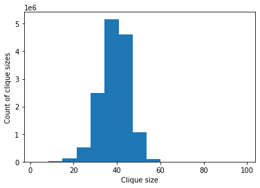

```python
# Histogram of clique sizes
plt.hist(clique_sz, bins=15)
plt.xlabel('Clique size')
plt.ylabel('Count of clique sizes')
plt.show()
```

```python
# Clique summary stats
print('Mean:', np.mean(clique_sz))
print('Median:', np.median(clique_sz))
print('Max:', np.max(clique_sz))
print('Min:', np.min(clique_sz))
print('Std dev:', np.std(clique_sz))
```

[output not shown]

### Ego graphs

Look at the ego graphs of the top books from each subgraph.

```
Large subgraph: Graph with 48 nodes and 0 edges
Small subgraph: Graph with 4 nodes and 0 edges
```

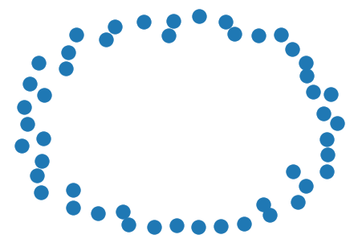

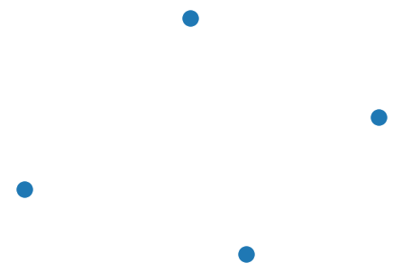

```python
# Get the ego graph of the top books from each subgraph
eg = nx.ego_graph(g, '067976402X', center=False)    # Snow Falling on Cedars
eg1 = nx.ego_graph(g, '2070375161', center=False)   # La Ferme Des Animaux
print('Large subgraph:', eg)
print('Small subgraph:', eg1)

# Draw ego graphs
plt.figure(1)
nx.draw(eg)
plt.figure(2)
nx.draw(eg1)
```

```python
# Show the first few readers - large graph
print('First few readers - large graph:')
df = pd.DataFrame(columns=['location', 'age', 'bipartite'])
for i, n in enumerate(eg.nodes):
    if i > 9: break
    #print(i+1, g.nodes(data=True)[n])
    tmpd = g.nodes(data=True)[n].copy()
    for k in tmpd.keys():
        tmpval = tmpd[k]
        tmpd[k] = []
        tmpd[k].append(tmpval)
    df = pd.concat([df, pd.DataFrame.from_dict(tmpd)], ignore_index=True)
display(df)
print()

# Show the first few readers - large graph
print('First few readers - small graph:')
df = pd.DataFrame(columns=['location', 'age', 'bipartite'])
for i, n in enumerate(eg1.nodes):
    if i > 9: break
    #print(i+1, g.nodes(data=True)[n])
    tmpd = g.nodes(data=True)[n].copy()
    for k in tmpd.keys():
        tmpval = tmpd[k]
        tmpd[k] = []
        tmpd[k].append(tmpval)
    df = pd.concat([df, pd.DataFrame.from_dict(tmpd)], ignore_index=True)
display(df)
print()
```

```
First few readers - large graph:
```

|  | location | age | bipartite | loc |
| --- | --- | --- | --- | --- |
| 0 | NaN | NULL | 0 | portland, oregon, usa |
| 1 | NaN | 33 | 0 | iowa city, iowa, usa |
| 2 | NaN | NULL | 0 | new york, new york, usa |
| 3 | NaN | 70 | 0 | river john, nova scotia, canada |
| 4 | NaN | 33 | 0 | kajang, selangor, malaysia |
| 5 | NaN | 47 | 0 | mechanicsville, maryland, usa |
| 6 | NaN | NULL | 0 | hamilton, , |
| 7 | NaN | NULL | 0 | n/a, n/a, n/a |
| 8 | NaN | 32 | 0 | puchong, selangor, malaysia |
| 9 | NaN | 27 | 0 | winnipeg, manitoba, canada |

```
First few readers - small graph:
```

|  | location | age | bipartite | loc |
| --- | --- | --- | --- | --- |
| 0 | NaN | NULL | 0 | paris, n/a, france |
| 1 | NaN | 47 | 0 | paris, ile-de-france, france |
| 2 | NaN | 22 | 0 | rennes, bretagne, france |
| 3 | NaN | NULL | 0 | n/a, n/a, n/a |

This shows that the readers are split by geographic location.

### Readership correlation

```python
# Generate list of subgraph indices to create
small_subgraph_indexes = list(range(1, 20))
small_subgraph_indexes.remove(4)

# Generate subgraphs
for i in small_subgraph_indexes:
    sg_tmp = g2.subgraph(cc[i])
    for n in sg_tmp.nodes(data=True):
        n[1]['subgraph'] = i
small_subgraphs = [n for n in g2.nodes(data=True) if 'subgraph' in g2.nodes(data=True)[n[0]].keys()]

# Create a dataframe to hold the book ISBNs
df1 = pd.DataFrame()
df1['isbn'] = [n[0] for n in small_subgraphs]
df1['subgraph'] = [n[1]['subgraph'] for n in small_subgraphs]

# Create a dataframe to hold the reader metadata
df2 = pd.DataFrame()
for book in df1['isbn']:
    eg_tmp = nx.ego_graph(g, book, center=False)
    for reader in eg_tmp.nodes(data=True):
        new_row = pd.DataFrame({'isbn': book, 'loc': reader[1]['loc'], 'age': reader[1]['age']}, index = [0])
        df2 = pd.concat([new_row, df2.loc[:]]).reset_index(drop=True)

# Split location field by city, state, and country
loc = df2['loc'].str.split(', ')

# Fix errant location
for i, l in enumerate(loc):
    if l[0] == 'indianapolis' and l[1] == 'indiana,':
        loc[i] = ['indianapolis', 'indiana', 'usa']

# Add city, state, and country to data frame
df2['city'] = [locality[0] for locality in loc]
df2['state'] = [locality[1] for locality in loc]
df2['country'] = [locality[2] for locality in loc]

# Create lookup for region, as divided by the US Census Bureau
state_dict = {}
s = """Northeast; New England; (Connecticut, Maine, Massachusetts, New Hampshire, Rhode Island, Vermont)
Northeast; Mid-Atlantic; (New Jersey, New York, Pennsylvania)
Midwest; East North Central; (Illinois, Indiana, Michigan, Ohio, Wisconsin)
Midwest; West North Central; (Iowa, Kansas, Minnesota, Missouri, Nebraska, North Dakota, South Dakota)
South; South Atlantic; (Delaware, Florida, Georgia, Maryland, North Carolina, South Carolina, Virginia, Washington D.C., West Virginia)
South; East South Central; (Alabama, Kentucky, Mississippi, Tennessee)
South; West South Central; (Arkansas, Louisiana, Oklahoma, Texas)
West; Mountain; (Arizona, Colorado, Idaho, Montana, Nevada, New Mexico, Utah, Wyoming)
West; Pacific; (Alaska, California, Hawaii, Oregon, Washington)"""
r1 = s.split('\n')
for r2 in r1:
    r3 = r2.split('; ')
    reg = r3[0]
    div = r3[1]
    states = r3[2].replace('(', '')    # remove parenthesis
    states = states.replace(')', '')    # remove parenthesis
    states = states.split(', ')
    for state in states:
        if state == 'Washington D.C.':
            state = 'Washington, D.C.'    # add comma
        state_dict[state.lower()] = {'region': reg, 'division': div}

# Populate dataframe with regions and division (if in the USA)
df2['region'] = ''      # seed with empty region
df2['division'] = ''    # seed with empty division
for row in df2.iterrows():
    if row[1]['country'] == 'usa':
        if row[1]['state'] in state_dict.keys():
            row[1]['region'] = state_dict[row[1]['state']]['region']
            row[1]['division'] = state_dict[row[1]['state']]['division']
display(df2)
```

|  | isbn | loc | age | city | state | country | region | division |
| --- | --- | --- | --- | --- | --- | --- | --- | --- |
| 0 | 0452281431 | byron, minnesota, usa | 18 | byron | minnesota | usa | Midwest | West North Central |
| 1 | 0452281431 | seattle, washington, usa | 26 | seattle | washington | usa | West | Pacific |
| 2 | 0452281431 | chicago, illinois, usa | 27 | chicago | illinois | usa | Midwest | East North Central |
| 3 | 0452281458 | seattle, washington, usa | 26 | seattle | washington | usa | West | Pacific |
| 4 | 0452281458 | byron, minnesota, usa | 18 | byron | minnesota | usa | Midwest | West North Central |
| ... | ... | ... | ... | ... | ... | ... | ... | ... |
| 145 | 1841721522 | palma de mallorca, baleares, spain | 37 | palma de mallorca | baleares | spain |  |  |
| 146 | 1841721522 | barcelona, catalunya, spain | 17 | barcelona | catalunya | spain |  |  |
| 147 | 1841721522 | mï¿½laga, andalucia, spain | 35 | mï¿½laga | andalucia | spain |  |  |
| 148 | 1841721522 | albacete, wisconsin, spain | 26 | albacete | wisconsin | spain |  |  |
| 149 | 1841721522 | cadiz, cadiz, spain | 30 | cadiz | cadiz | spain |  |  |

150 rows × 8 columns

```python
# Regions
df3 = pd.DataFrame(df2.loc[df2['country'] == 'usa'].groupby(['isbn'], as_index=False).agg(regions=('region', 'nunique'), count=('region', 'size')))
df3['variability'] = df3['regions']/df3['count']
print(df3.describe())
```

```
         regions      count  variability
count  35.000000  35.000000    35.000000
mean    2.085714   2.628571     0.819388
std     0.886879   1.139807     0.221225
min     1.000000   1.000000     0.428571
25%     1.000000   2.000000     0.666667
50%     2.000000   3.000000     1.000000
75%     3.000000   3.000000     1.000000
max     4.000000   7.000000     1.000000
```

The average variability in the region data is 0.82, so there is too much variation in the region to say that there is a statistical correlation.

```python
# Age
df2 = df2.replace('NULL', np.nan)
df2['age'] = df2['age'].astype(float)
df4 = pd.DataFrame(df2.loc[(df2['age'] != np.nan) & (df2['age'] < 120)].groupby(['isbn'], as_index=False).agg(min_age=('age', 'min'), max_age=('age', 'max')))
df4['age_range'] = df4['max_age'] - df4['min_age']
print(df4.describe())
```

```
         min_age    max_age  age_range
count  38.000000  38.000000  38.000000
mean   22.368421  40.157895  17.789474
std     7.309457  11.881228  14.443100
min     8.000000  18.000000   0.000000
25%    18.000000  32.500000   9.500000
50%    23.000000  41.000000  16.500000
75%    27.000000  46.000000  23.250000
max    34.000000  68.000000  55.000000
```

Based on the fact that the mean age range is 17.8 years, there doesn't seem to be statistical evidence that the books attract readers of the same age range.

### Analysis and conclusions

Based on the results, a few conclusions can be drawn:

1. Partitioning the network into subgraphs makes it clear that the groups were separated by the readers' language (English for the large subgraph, French for the small one).
2. In the large subgraph, *Snow Falling on Cedars* and *Divine Secrets of the Ya-Ya Sisterhood* were in the top four for all centrality degree metrics, which suggests that they were widely read.
3. *Divine Secrets of the Ya-Ya Sisterhood* had the highest eigenvector centrality, indicating that it was read by the most prolific readers.
4. *Wild Animus* had the highest betweenness centrality, suggesting that it was a cross-over book of sorts that possibly spanned genres.
5. *Snow Falling on Cedars* tops the closeness centrality chart, so it can be infered that it was the one that appealed to a wide audience.
6. In the small subgraph, Orwell's translation of *Animal Farm* (*La Ferme Des Animaux*) ranked either first or second by all centrality metrics.
7. Clique sizes within the large subgroup are normally distributed with a mean of 38.9, which could mean that most readers on the site review about that many books, or that the same several readers review about that many books.
8. The ego graphs of the top books confirm that the readers are, indeed, separated by language, as infered by geographic location of the reader.
9. However, there does not seem to be the same kind of correlation among readers based on their age or their region of the US.